# Project Foundations for Data Science: FoodHub Data Analysis

**Marks: 60**

### Context

The number of restaurants in New York is increasing day by day. Lots of students and busy professionals rely on those restaurants due to their hectic lifestyles. Online food delivery service is a great option for them. It provides them with good food from their favorite restaurants. A food aggregator company FoodHub offers access to multiple restaurants through a single smartphone app.

The app allows the restaurants to receive a direct online order from a customer. The app assigns a delivery person from the company to pick up the order after it is confirmed by the restaurant. The delivery person then uses the map to reach the restaurant and waits for the food package. Once the food package is handed over to the delivery person, he/she confirms the pick-up in the app and travels to the customer's location to deliver the food. The delivery person confirms the drop-off in the app after delivering the food package to the customer. The customer can rate the order in the app. The food aggregator earns money by collecting a fixed margin of the delivery order from the restaurants.

### Objective

The food aggregator company has stored the data of the different orders made by the registered customers in their online portal. They want to analyze the data to get a fair idea about the demand of different restaurants which will help them in enhancing their customer experience. Suppose you are hired as a Data Scientist in this company and the Data Science team has shared some of the key questions that need to be answered. Perform the data analysis to find answers to these questions that will help the company to improve the business.

### Data Description

The data contains the different data related to a food order. The detailed data dictionary is given below.

### Data Dictionary

- order_id: Unique ID of the order
- customer_id: ID of the customer who ordered the food
- restaurant_name: Name of the restaurant
- cuisine_type: Cuisine ordered by the customer
- cost: Cost of the order
- day_of_the_week: Indicates whether the order is placed on a weekday or weekend (The weekday is from Monday to Friday and the weekend is Saturday and Sunday)
- rating: Rating given by the customer out of 5
- food_preparation_time: Time (in minutes) taken by the restaurant to prepare the food. This is calculated by taking the difference between the timestamps of the restaurant's order confirmation and the delivery person's pick-up confirmation.
- delivery_time: Time (in minutes) taken by the delivery person to deliver the food package. This is calculated by taking the difference between the timestamps of the delivery person's pick-up confirmation and drop-off information

### Let us start by importing the required libraries

```python
# import libraries for data manipulation
import numpy as np
import pandas as pd

# import libraries for data visualization
import matplotlib.pyplot as plt
import seaborn as sns
```

### Understanding the structure of the data

```python
# read the data
df = pd.read_csv('foodhub_order.csv')
# returns the first 5 rows
df.head()
```

|  | order_id | customer_id | restaurant_name | cuisine_type | cost_of_the_order | day_of_the_week | rating | food_preparation_time | delivery_time |
| --- | --- | --- | --- | --- | --- | --- | --- | --- | --- |
| 0 | 1477147 | 337525 | Hangawi | Korean | 30.75 | Weekend | Not given | 25 | 20 |
| 1 | 1477685 | 358141 | Blue Ribbon Sushi Izakaya | Japanese | 12.08 | Weekend | Not given | 25 | 23 |
| 2 | 1477070 | 66393 | Cafe Habana | Mexican | 12.23 | Weekday | 5 | 23 | 28 |
| 3 | 1477334 | 106968 | Blue Ribbon Fried Chicken | American | 29.20 | Weekend | 3 | 25 | 15 |
| 4 | 1478249 | 76942 | Dirty Bird to Go | American | 11.59 | Weekday | 4 | 25 | 24 |

#### Observations:

The DataFrame has 9 columns as mentioned in the Data Dictionary. Data in each row corresponds to the order placed by a customer.

### **Question 1:** How many rows and columns are present in the data? [0.5 mark]

```python
df.shape
```

```
(1898, 9)
```

#### Observations:

There are 1898 rows, with 9 columns in the dataset.

### **Question 2:** What are the datatypes of the different columns in the dataset? (The info() function can be used) [0.5 mark]

```python
# Use info() to print a concise summary of the DataF- rame
df.info()
```

```
<class 'pandas.core.frame.DataFrame'>
RangeIndex: 1898 entries, 0 to 1897
Data columns (total 9 columns):
 #   Column                 Non-Null Count  Dtype
---  ------                 --------------  -----
 0   order_id               1898 non-null   int64
 1   customer_id            1898 non-null   int64
 2   restaurant_name        1898 non-null   object
 3   cuisine_type           1898 non-null   object
 4   cost_of_the_order      1898 non-null   float64
 5   day_of_the_week        1898 non-null   object
 6   rating                 1898 non-null   object
 7   food_preparation_time  1898 non-null   int64
 8   delivery_time          1898 non-null   int64
dtypes: float64(1), int64(4), object(4)
memory usage: 133.6+ KB
```

### **Question 3:** Are there any missing values in the data? If yes, treat them using an appropriate method. [1 mark]

```python
# Write your code here
df.isnull().sum()
```

```
order_id                 0
customer_id              0
restaurant_name          0
cuisine_type             0
cost_of_the_order        0
day_of_the_week          0
rating                   0
food_preparation_time    0
delivery_time            0
dtype: int64
```

#### Observations:

There are no missing values in the given dataset.

### **Question 4:** Check the statistical summary of the data. What is the minimum, average, and maximum time it takes for food to be prepared once an order is placed? [2 marks]

```python
# Write your code here
df.food_preparation_time.describe()
```

```
count    1898.000000
mean       27.371970
std         4.632481
min        20.000000
25%        23.000000
50%        27.000000
75%        31.000000
max        35.000000
Name: food_preparation_time, dtype: float64
```

#### Observations:

Based on above statistical summary for food_preparation_time, the minimum, average and maximum time for food preparation in 20.0, 27.37 and 35 minutes respectively.

### **Question 5:** How many orders are not rated? [1 mark]

```python
# Write the code here
df[df.rating =="Not given"]["order_id"].count()
```

```
736
```

#### Observations:

There are 736 orders that does not have rating.

### Exploratory Data Analysis (EDA)

### **Question 6:** Explore all the variables and provide observations on their distributions. (Generally, histograms, boxplots, countplots, etc. are used for univariate exploration.) [9 marks]

```python
import warnings
warnings.simplefilter(action='ignore')
```

### Dataset overview

```python
df.describe()
```

|  | order_id | customer_id | cost_of_the_order | food_preparation_time | delivery_time |
| --- | --- | --- | --- | --- | --- |
| count | 1.898000e+03 | 1898.000000 | 1898.000000 | 1898.000000 | 1898.000000 |
| mean | 1.477496e+06 | 171168.478398 | 16.498851 | 27.371970 | 24.161749 |
| std | 5.480497e+02 | 113698.139743 | 7.483812 | 4.632481 | 4.972637 |
| min | 1.476547e+06 | 1311.000000 | 4.470000 | 20.000000 | 15.000000 |
| 25% | 1.477021e+06 | 77787.750000 | 12.080000 | 23.000000 | 20.000000 |
| 50% | 1.477496e+06 | 128600.000000 | 14.140000 | 27.000000 | 25.000000 |
| 75% | 1.477970e+06 | 270525.000000 | 22.297500 | 31.000000 | 28.000000 |
| max | 1.478444e+06 | 405334.000000 | 35.410000 | 35.000000 | 33.000000 |

#### Observations:

Above table gives an overview of numerical columns in the dataset. However aggregate values for some columns does not make sense, e.g. order_id is a unique identifier for a row and it does not makes sense to calculate aggregate values on it. Similarly, value of customer_id does not signify quantity. That is why aggregate values for order_id and customer_id should be ignored.

### 1- Order ID

```python
df['order_id'].count()
```

```
1898
```

#### Observations:

- There are 1898 unique orders placed by the customers using app. This field is a unique identifier, that is why it does not make sense to explore it

### 2- Customer ID

```
Total number of distinct customers:  1200
Single order customer:  784 , which is  65.33 % of total customers.
```

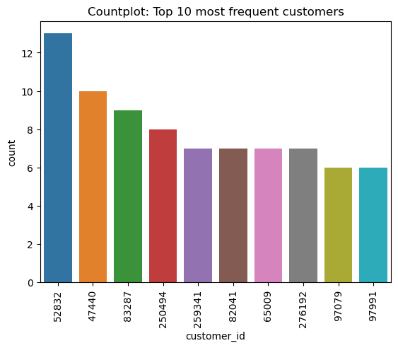

```python
# Total number of customers
total_customer = df['customer_id'].value_counts().shape[0]
print("Total number of distinct customers: ", total_customer)

# Customers who make an order only once using the app
single_order = len([x for x in df['customer_id'].value_counts() if x == 1])
single_order_percent = single_order / total_customer * 100
print("Single order customer: ", single_order, ", which is ", round(single_order_percent,2), "% of total customers.", )

#Top 10 most frequent customers
sns.countplot(data=df, x='customer_id', order=df['customer_id'].value_counts().index[:10])
plt.xticks(rotation=90)
plt.title("Countplot: Top 10 most frequent customers")
plt.show()
```

#### Observations:

- Based on the given dataset, there are 1200 customser using the app.
- The above countplot displays 10 most frequent customs
- Single order customer: 784 , which is 65.33 % of total customers.

### 3- Restaurant name

```
Total restaurant using app: 178
Single order restaurant: 50 , which is 28.09 % of all restaurant.
```

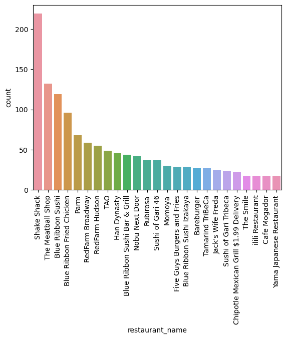

```python
# Total number of restaurants who recei ved orders from the app
restaurants = df['restaurant_name'].value_counts().shape[0]
print("Total restaurant using app:", restaurants)

# Number of resturants which received single order so far
single_order = len([x for x in df['restaurant_name'].value_counts() if x == 1])
single_order_percent = single_order / restaurants * 100
print("Single order restaurant:", single_order, ", which is", round(single_order_percent,2), "% of all restaurant.", )

#Countplot of restaurants and number of orders they received
sns.countplot(data=df,
              x='restaurant_name',
              order=df['restaurant_name'].value_counts().index[:25])
plt.xticks(rotation=90)
plt.show()
```

#### Observations:

There are 178 restaurants using this app to fulfil customer orders. Out of which 50 restuarant had single order so far, which is 28.09 % of all restaurant.

### 4- Cuisine Type

```
Number of cuisine_type : 14
```

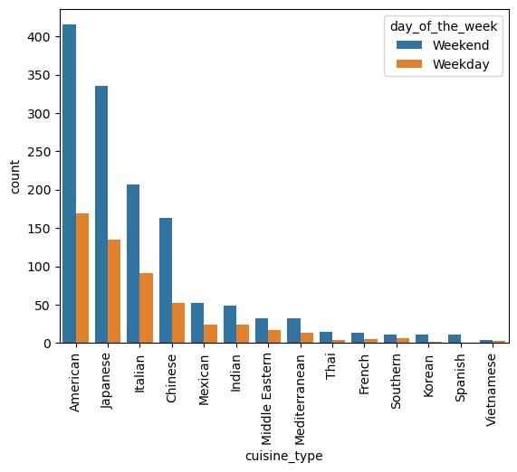

```python
# Number of cuisine types for which customers have made order
cuisine_type = df['cuisine_type'].value_counts().shape[0]
print("Number of cuisine_type :", cuisine_type)

# Order count per cuisine, for the different day of the week
sns.countplot(data=df,
              x='cuisine_type',
              hue='day_of_the_week',
              order=df['cuisine_type'].value_counts().index)
plt.xticks(rotation=90)
plt.show()
```

#### Observations:

There are 14 cuisine types offered in the restaurant, in which American is the most popular one, followed by Japanese and the Italian. However, Vietnamese is the least popular of all.

### 5- Cost of the order

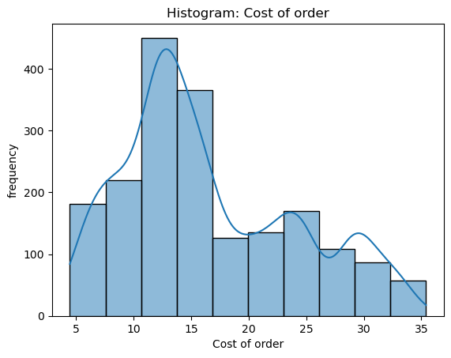

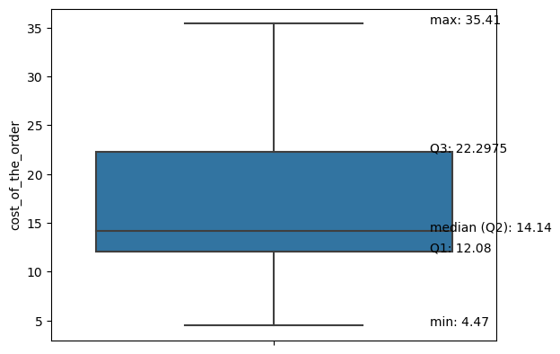

```python
# Histogrm of Cost of the order
sns.histplot(df['cost_of_the_order'], bins=10, kde=True)
plt.title("Histogram: Cost of order")
plt.xlabel("Cost of order")
plt.ylabel("frequency")
plt.show()

# Boxplot of  Cost of the order
sns.boxplot(y=df['cost_of_the_order'])
plt.text(x=0.35, y=df['cost_of_the_order'].min(), s='min: ' + str(df['cost_of_the_order'].min()))
plt.text(x=0.35, y=df['cost_of_the_order'].quantile(0.25), s='Q1: ' + str(df['cost_of_the_order'].quantile(0.25)))
plt.text(x=0.35, y=df['cost_of_the_order'].median(), s='median (Q2): ' + str(df['cost_of_the_order'].median()))
plt.text(x=0.35, y=df['cost_of_the_order'].quantile(0.75), s='Q3: ' + str(df['cost_of_the_order'].quantile(0.75)))
plt.text(x=0.35, y=df['cost_of_the_order'].max(), s='max: ' + str(df['cost_of_the_order'].max()))
plt.show()
```

#### Observations:

- The range of cost_of_the_order is 4.47 - 35.41 with the median of 14.14
- Histogram for 'cost of order' is right skewed i.e. median-Q1 < Q3-median (14.14-12.08 < 22.29-14.14 => 2.06 < 8.15)
- There are no outliers

### 6- Day of the week

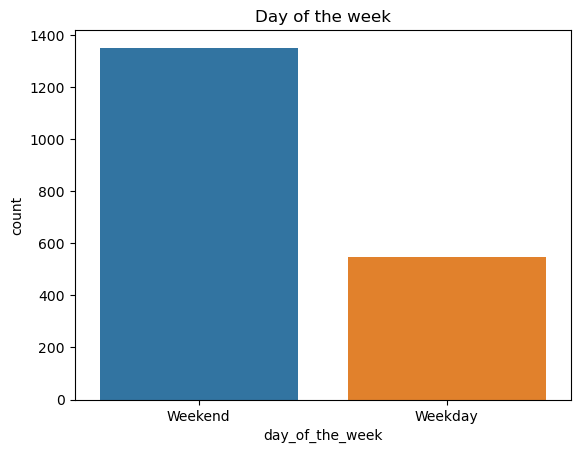

```python
# Count plot of day of the week
sns.countplot(data=df, x='day_of_the_week')
plt.title("Day of the week")
plt.show()
```

#### Observations:

Orders received over the weekend is much higher than weekdays i.e Number of orders are more than doubled over the weekend (i.e. Saturday and Sunday, 2 days) as compare to weekdays (i.e. 5 week days)

### 7- Rating

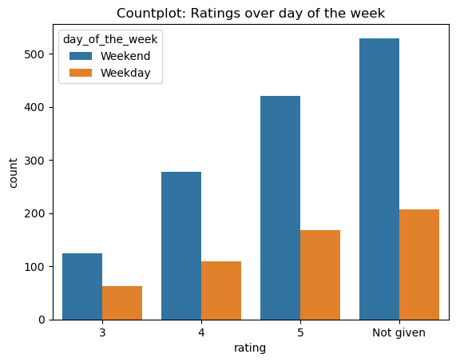

```python
# Count plot of rating, over the day of the week
sns.countplot(data=df, x='rating', hue='day_of_the_week', order=df['rating'].value_counts().index[::-1])
plt.title("Countplot: Ratings over day of the week")
plt.show()
```

### 8- Food perparation time

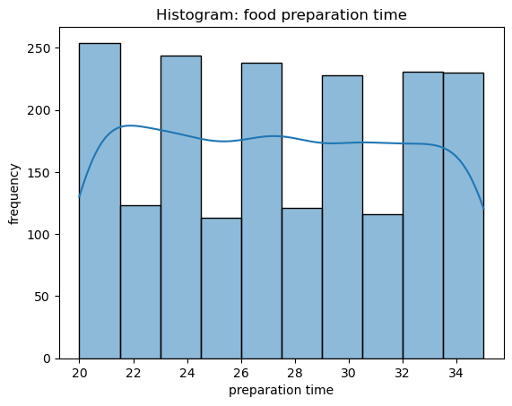

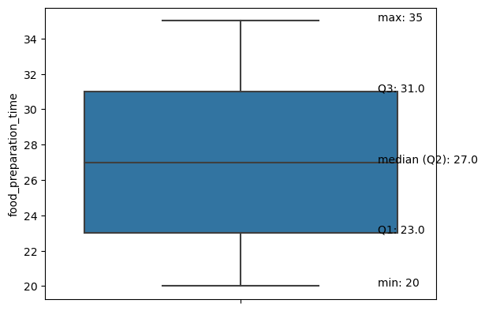

```python
# Histogram of food preparation time
sns.histplot(df['food_preparation_time'], bins=10, kde=True)
plt.title("Histogram: food preparation time")
plt.xlabel("preparation time")
plt.ylabel("frequency")
plt.show()

# Boxplot of food preparation time
sns.boxplot(data = df, y='food_preparation_time')
plt.text(x=0.35, y=df['food_preparation_time'].min(), s='min: ' + str(df['food_preparation_time'].min()))
plt.text(x=0.35, y=df['food_preparation_time'].quantile(0.25), s='Q1: ' + str(df['food_preparation_time'].quantile(0.25)))
plt.text(x=0.35, y=df['food_preparation_time'].median(), s='median (Q2): ' + str(df['food_preparation_time'].median()))
plt.text(x=0.35, y=df['food_preparation_time'].quantile(0.75), s='Q3: ' + str(df['food_preparation_time'].quantile(0.75)))
plt.text(x=0.35, y=df['food_preparation_time'].max(), s='max: ' + str(df['food_preparation_time'].max()))
plt.show()
```

### 9-Delivery TIme

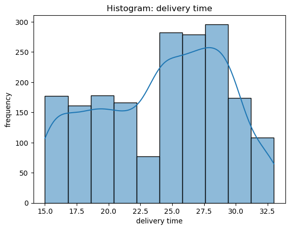

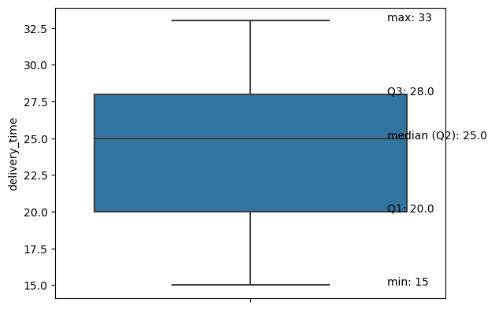

```python
# Histogram of delivery time
sns.histplot(df['delivery_time'], bins=10, kde=True)
plt.title("Histogram: delivery time")
plt.xlabel("delivery time")
plt.ylabel("frequency")
plt.show()

# Bosplot of delivery time
sns.boxplot(data = df, y='delivery_time')
plt.text(x=0.35, y=df['delivery_time'].min(), s='min: ' + str(df['delivery_time'].min()))
plt.text(x=0.35, y=df['delivery_time'].quantile(0.25), s='Q1: ' + str(df['delivery_time'].quantile(0.25)))
plt.text(x=0.35, y=df['delivery_time'].median(), s='median (Q2): ' + str(df['delivery_time'].median()))
plt.text(x=0.35, y=df['delivery_time'].quantile(0.75), s='Q3: ' + str(df['delivery_time'].quantile(0.75)))
plt.text(x=0.35, y=df['delivery_time'].max(), s='max: ' + str(df['delivery_time'].max()))
plt.show()
```

#### Observations:

Mean of delivery time is 24, which is slightly less than median (i.e. 25), Hence the delivery time distribution is slightly left skewed, with minimum of 15 minutes and maximum of 33 minutes.

### **Question 7**: Which are the top 5 restaurants in terms of the number of orders received? [1 mark]

```python
df["restaurant_name"].value_counts()[:5]
```

```
Shake Shack                  219
The Meatball Shop            132
Blue Ribbon Sushi            119
Blue Ribbon Fried Chicken     96
Parm                          68
Name: restaurant_name, dtype: int64
```

#### Observations:

Based on given dataset, top 5 restaurants in terms of the number of orders revceived are:

- Shake Shack, with 219 orders
- The Meatball Shop, with 132 orders
- Blue Ribbon Sushi, with 119 orders
- Blue Ribbon Fried Chicken with 96 orders
- Parm, with 68 orders

### **Question 8**: Which is the most popular cuisine on weekends? [1 mark]

```
cuisine_type
American    415
Name: order_id, dtype: int64
```

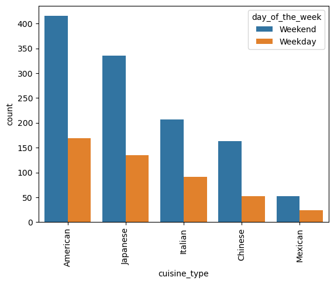

```python
# filter all the rows that are placed over the Weekend
# group by cuisine_type
# Count each cuisine type orders(rows)
# sort counted rows
# Display top 5 most popular cuisine

most_popular_cuisine = df[df['day_of_the_week'] =='Weekend'].groupby('cuisine_type').count().sort_values(by='cuisine_type').head(1)['order_id']
print(most_popular_cuisine)
sns.countplot(data=df,
              x='cuisine_type',
             hue='day_of_the_week',
             order=df['cuisine_type'].value_counts().index[:5])
plt.xticks(rotation=90)
plt.show()
```

#### Observations:

American is the most popular cuisine on weekends, with 415 orders

### **Question 9**: What percentage of the orders cost more than 20 dollars? [2 marks]

```python
percentage = df.loc[df['cost_of_the_order'] > 20].shape[0]/df.shape[0] * 100
print(round(percentage, 2), '%')
```

```
29.24 %
```

#### Observations:

Around 30 percent of orders have order cost more than 20 dollars.

### **Question 10**: What is the mean order delivery time? [1 mark]

```python
print(round(df.delivery_time.mean(), 2), 'minutes')
```

```
24.16 minutes
```

#### Observations:

The mean order delivery time is around 24 minutes.

### **Question 11:** The company has decided to give 20% discount vouchers to the top 3 most frequent customers. Find the IDs of these customers and the number of orders they placed. [1 mark]

```python
df["customer_id"].value_counts().sort_values(ascending=False)[:3]
```

```
52832    13
47440    10
83287     9
Name: customer_id, dtype: int64
```

#### Observations:

Customer ID's of the top 3 most frequently customers are:  
52832, with 13 orders  
47440, with 10 orders  
83287, with 9 orders

### **Question 12**: Perform a multivariate analysis to explore relationships between the important variables in the dataset. (It is a good idea to explore relations between numerical variables as well as relations between numerical and categorical variables) [10 marks]

### 1- Relationship b/w restaurant and delivery time

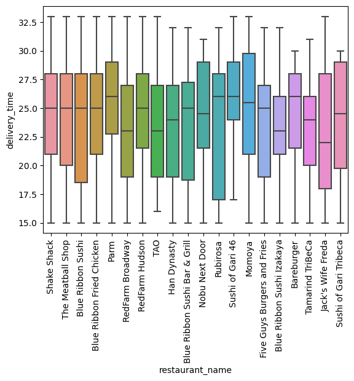

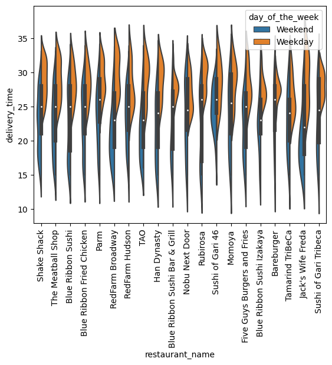

```python
# Boxplot of resturant names, and their delivery time
sns.boxplot(data=df,x='restaurant_name',y='delivery_time', order=df['restaurant_name'].value_counts().index[:20])
plt.xticks(rotation=90)
plt.show()

# Violin plot for resturant names, and their delivery time, over the days of the week
sns.violinplot(data=df,
               x='restaurant_name',
               y='delivery_time',
               hue='day_of_the_week',
               order=df['restaurant_name'].value_counts().index[:20],
               split=True)
plt.xticks(rotation=90)
plt.show()
```

#### Observations:

Delivery time is similar across top 20 most popular resturants. However, the distribution is not symmetric for weekend and weekday. Average delivery time is higher during weekdays

### 2- Relationship b/w food preparation time and cuisine type

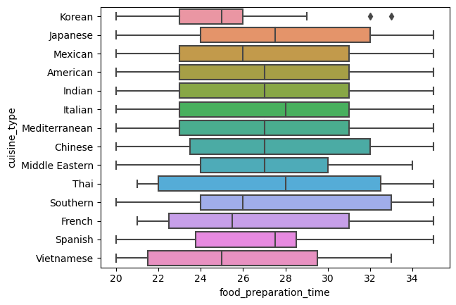

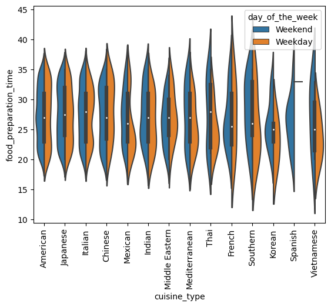

```python
# Boxplot of cuisine type, and their respective preparation time
sns.boxplot(data=df,x='food_preparation_time',y='cuisine_type')
plt.show()

# Violin plot for cuisine type, and their preparation time, over the days of the week
sns.violinplot(data=df,
               x='cuisine_type',
               y='food_preparation_time',
               hue='day_of_the_week',
               order=df['cuisine_type'].value_counts().index,
               split=True)
plt.xticks(rotation=90)
plt.show()
```

### 3- Correlation amongst numerical variables

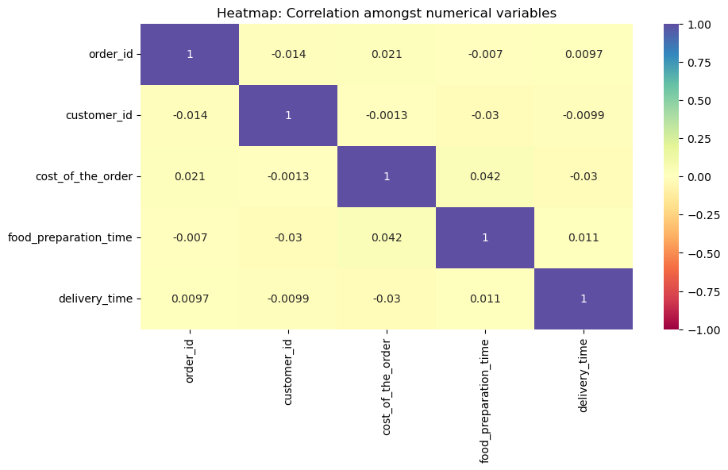

```python
# Heatmap of all numeric variables to access correlation amangst them
plt.figure(figsize=(10,5))
sns.heatmap(df.corr(),annot=True, cmap='Spectral', vmin=-1, vmax=1)
plt.title('Heatmap: Correlation amongst numerical variables')
plt.show()
```

### 4- Pairplot

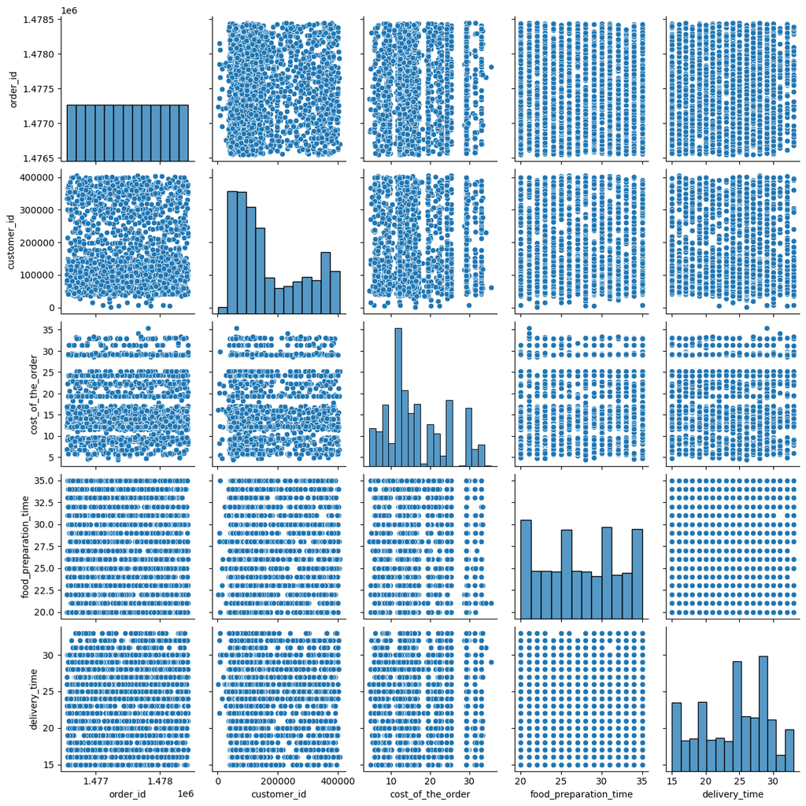

```python
# Pai plot of all numeric variables to access correlation amangst them
plt.figure(figsize=(8,8))
sns.pairplot(data=df)
plt.show()
```

#### Observations:

Pairplot also confirms what we have observed in heatmap analysis

### 5- Cuisine_type and day_of the_week

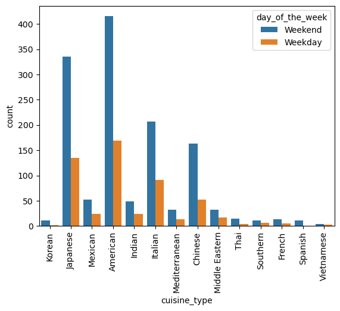

```python
# Count plot of cuisine type, over the day of the week
sns.countplot(data=df,x='cuisine_type',hue= 'day_of_the_week')
plt.xticks(rotation=90)
plt.show()
```

#### Observation

American cuisine is very popular over the weekend, followed by Japanese and Italian cuisine. Weekdays statistics also shows similar trend.

### **Question 13:** The company wants to provide a promotional offer in the advertisement of the restaurants. The condition to get the offer is that the restaurants must have a rating count of more than 50 and the average rating should be greater than 4. Find the restaurants fulfilling the criteria to get the promotional offer. [3 marks]

```python
# Introduce a column where 'Not given' is represented as NaN
# and have it float dtype so I can generate aggregate data of that column
df['rated'] = np.where(df['rating']== 'Not given', np.nan ,df['rating']).astype(float)

# Generate aggregate data (i.e. count and mean)
restaurant_rating = df.groupby('restaurant_name')['rated'].agg(['count','mean'])

# Filter resturants who has more than 50 ratings and average rating is more than 4
restaurant_rating.loc[(restaurant_rating['count'] > 50) & (restaurant_rating['mean'] > 4)].sort_values(by='mean', ascending=False)
```

| restaurant_name | count | mean |
| --- | --- | --- |
| The Meatball Shop | 84 | 4.511905 |
| Blue Ribbon Fried Chicken | 64 | 4.328125 |
| Shake Shack | 133 | 4.278195 |
| Blue Ribbon Sushi | 73 | 4.219178 |

#### Observations:

Resturants that have more than 50 ratings and their mean rating is more than 4 are:

- The Meatball Shop
- Blue Ribbon Fried Chicken
- Shake Shack
- Blue Ribbon Sushi

### **Question 14:** The company charges the restaurant 25% on the orders having cost greater than 20 dollars and 15% on the orders having cost greater than 5 dollars. Find the net revenue generated by the company across all orders. [3 marks]

```python
# Function to calculate revenue
def calculate_revenue(cost):
    if cost > 20:
        return cost*0.25
    elif cost > 5:
        return cost*0.15
    else:
        return 0


# Add a column 'revenue' and call calculate_revenue function to populate it
df['revenue'] = df['cost_of_the_order'].apply(calculate_revenue)
print(df['revenue'].sum())
```

```
6166.303
```

#### Observations:

The net revenue generated by the company across all orders is 6166.30

### **Question 15:** The company wants to analyze the total time required to deliver the food. What percentage of orders take more than 60 minutes to get delivered from the time the order is placed? (The food has to be prepared and then delivered.) [2 marks]

```python
# Total order time
df['total_time'] = df['food_preparation_time'] + df['delivery_time']

# percentage of orders take more than 60 minutes
percentage = df[df['total_time'] > 60].shape[0] / df.shape[0] * 100
print(round(percentage, 2), '%')
```

```
10.54 %
```

#### Observations:

Around 10.54 % of the orders takes more than 60 minutes to get delivered from the time the order is placed.

### **Question 16:** The company wants to analyze the delivery time of the orders on weekdays and weekends. How does the mean delivery time vary during weekdays and weekends? [2 marks]

```
                delivery_time
                        count       mean       std
day_of_the_week
Weekday                   547  28.340037  2.891428
Weekend                  1351  22.470022  4.628938
```

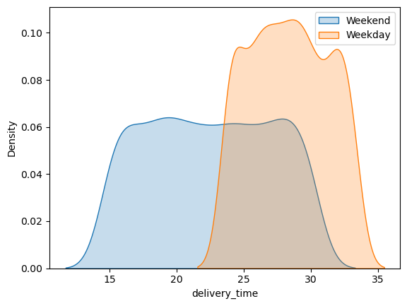

```python
# Generate aggregate data for delivery time
print(df.groupby('day_of_the_week')[['delivery_time']].agg(['count', 'mean', 'std']))

# Generate distribution graph for each day of the week (i.e. weekend and weekday)
time = ['Weekend', 'Weekday']
for t in time:
    subset = df[df['day_of_the_week'] == t]
    sns.distplot(subset['delivery_time'], hist=False, kde=True, kde_kws= {"shade": True}, label=t)
plt.legend(labels=time)
plt.show()
```

#### Observations:

The average delivery time over the weekend is shorter than weekdays, however it has high std. that is why the distribution is scattered for the weekends. Some orders can be delivered very quickly within 10-15 minutes, however some order might take more than 25-30 minutes. As compare to during weekdays, where mean delivery time is a bit high, however delivery timedf is consistent, as it has less std.

### Recommendations:

- Encourage users to rate their overall experince.
- Have more resturants on board to use this app to receive orders.
- Offer discounts or coupons, to motivate customers to make more orders using this app.
- Work with resturants to offer popular cuisines, such as American, Japanese, Italian, etc.
- Cordinate with resturant and figure out how to reduce total order time (i.e. food_preparation_time + delivery_time)
- Recommend customer to select resturant near them, to cut down total order time